# Análisis del régimen de precipitación en Cantabria: tendencias, rachas e índices de estacionalidad

# Sección 8 - Distribución mensual y estacional de las precipitaciones

## 8.1 - Tendencias mensuales

`tabla_mk_mensual()` aplica el pipeline estadístico completo (autocorrelación, selección MK/TFPW, Sen y Pettitt) a la precipitación mensual acumulada de cada uno de los 12 meses del año, iterando con `map_dfr(1:12, ...)`.

Los meses con menos de 10 observaciones se omiten. Los resultados se presentan en tablas formateadas con `add_header_above()` para Tama y Santander. Este análisis permite identificar en qué meses concretos la precipitación muestra tendencias significativas, más allá del análisis anual agregado.

```r
# Tendencia mensual de precipitación (Mann-Kendall + Sen + Pettitt)
tabla_mk_mensual <- function(df_raw, estacion_label = "") {

  meses <- c("Ene","Feb","Mar","Abr","May","Jun","Jul","Ago","Sep","Oct","Nov","Dic")

  # Agregación mensual de precipitación
  df <- df_raw %>%
    filter(!is.na(prec)) %>%
    group_by(anio, mes) %>%
    summarise(prec_mensual = sum(prec), .groups = "drop")

  map_dfr(1:12, function(m) {

    serie <- df %>% filter(mes == m) %>% arrange(anio)
    vals  <- serie$prec_mensual
    anios <- serie$anio

    if (length(vals) < 10) return(NULL)

    # Corrección por autocorrelación (TFPW vs estándar)
    acf1 <- acf(vals, lag.max = 1, plot = FALSE)$acf[2]
    tfpw <- abs(acf1) > 1.96 / sqrt(length(vals))

    mk <- if (tfpw) tfpwmk(vals) else mk.test(vals)

    tau  <- if (tfpw) unname(mk[grep("Tau", names(mk), ignore.case = TRUE)]) else unname(mk$estimates["tau"])
    pval <- if (tfpw) unname(mk[grep("p.value|P.value", names(mk), ignore.case = TRUE)]) else mk$p.value

    sen <- sens.slope(vals)
    pt  <- pettitt.test(vals)
    k   <- as.integer(pt$estimate[1])

    tibble(
      estacion = estacion_label,
      mes = m,
      mes_label = factor(meses[m], levels = meses),
      metodo = ifelse(tfpw, "tfpw", "estandar"),
      tau = round(tau, 3),
      p_valor = round(pval, 4),
      sen_slope = round(sen$estimates, 3),

      signif = case_when(pval < 0.01 ~ "**", pval < 0.05 ~ "*", pval < 0.10 ~ ".", TRUE ~ ""),

      K_anio = if (k <= length(anios)) anios[k] else NA,
      p_pt = round(pt$p.value, 4),

      signif_pt = case_when(pt$p.value < 0.01 ~ "**", pt$p.value < 0.05 ~ "*",
                            pt$p.value < 0.10 ~ ".", TRUE ~ "")
    )
  })
}

mk_mensual_tama <- tabla_mk_mensual(datos_tama_sin_NA, "Tama")
mk_mensual_santander <- tabla_mk_mensual(datos_santander_limpios, "Santander")

# ─────────────────────────────────────────────────────────────
# Tablas de tendencias mensuales (MK + Sen + Pettitt)
# ─────────────────────────────────────────────────────────────

cols <- c("Estación","Mes","Mes","Método","Tau","p-valor", "Pendiente","Signif.","Año cambio",
          "p-valor Pettitt","Signif. Pettitt")
dig <- c(NA,0,NA,NA,3,4,3,NA,0,4,NA)
cabecera <- c(" "=3,"Mann-Kendall"=3,"Pendiente de Sen"=2,"Pettitt"=3)
caption_txt <- paste("Resultados de tendencia mensual (Mann-Kendall y Sen) y cambios (Pettitt).",
                     "Significancia: ** p<0,01; * p<0,05; . p<0,10.")

mk_mensual_tama %>%
  knitr::kable(col.names=cols, digits=dig, caption=caption_txt) %>%
  add_header_above(cabecera) %>%
  kableExtra::kable_styling(
    bootstrap_options=c("striped","hover","condensed"),
    full_width=FALSE, position="center"
  )
```

Resultados de tendencia mensual (Mann-Kendall y Sen) y cambios (Pettitt). Significancia: ** p<0,01; * p<0,05; . p<0,10.

Mann-Kendall

Pendiente de Sen

Pettitt

Estación

Mes

Mes

Método

Tau

p-valor

Pendiente

Signif.

Año cambio

p-valor Pettitt

Signif. Pettitt

Tama

1

Ene

estandar

0.029

0.7700

0.171

1993

0.9018

Tama

2

Feb

estandar

0.016

0.8710

0.110

1974

1.0000

Tama

3

Mar

estandar

0.057

0.5587

0.155

2003

0.4905

Tama

4

Abr

estandar

-0.307

0.0015

-1.103

1992

0.0190

Tama

5

May

estandar

-0.117

0.2293

-0.337

2010

0.5221

Tama

6

Jun

estandar

0.191

0.0467

0.465

2005

0.0397

Tama

7

Jul

estandar

-0.207

0.0312

-0.353

2004

0.0550

.

Tama

8

Ago

estandar

-0.148

0.1239

-0.200

2003

0.2735

Tama

9

Sep

estandar

-0.024

0.8075

-0.078

2009

0.7971

Tama

10

Oct

estandar

-0.121

0.2242

-0.593

1975

0.7301

Tama

11

Nov

tfpw

0.109

0.2736

0.700

1994

0.2051

Tama

12

Dic

estandar

-0.020

0.8409

-0.130

1982

0.7036

```r
mk_mensual_santander %>%
  knitr::kable(col.names=cols, digits=dig, caption=caption_txt) %>%
  add_header_above(cabecera) %>%
  kableExtra::kable_styling(
    bootstrap_options=c("striped","hover","condensed"),
    full_width=FALSE, position="center"
  )
```

Resultados de tendencia mensual (Mann-Kendall y Sen) y cambios (Pettitt). Significancia: ** p<0,01; * p<0,05; . p<0,10.

Mann-Kendall

Pendiente de Sen

Pettitt

Estación

Mes

Mes

Método

Tau

p-valor

Pendiente

Signif.

Año cambio

p-valor Pettitt

Signif. Pettitt

Santander

1

Ene

estandar

-0.044

0.6142

-0.310

1986

0.4463

Santander

2

Feb

estandar

-0.096

0.2674

-0.459

1989

0.2320

Santander

3

Mar

estandar

-0.121

0.1616

-0.598

1986

0.1676

Santander

4

Abr

estandar

-0.270

0.0018

-1.400

1994

0.0147

Santander

5

May

estandar

-0.172

0.0476

-0.544

1985

0.0336

Santander

6

Jun

estandar

0.031

0.7219

0.071

2006

0.5307

Santander

7

Jul

estandar

-0.025

0.7804

-0.071

2011

1.0000

Santander

8

Ago

estandar

-0.076

0.3833

-0.224

1997

0.6442

Santander

9

Sep

estandar

0.054

0.5373

0.200

1974

0.7057

Santander

10

Oct

estandar

-0.129

0.1381

-0.735

1983

0.6376

Santander

11

Nov

estandar

-0.007

0.9385

-0.047

1971

0.4570

Santander

12

Dic

tfpw

-0.095

0.2796

-0.283

1982

0.2097

`plot_prec_mensual_mk()` visualiza los resultados en un panel de 12 facetas (4 columnas × 3 filas, escalas libres en y). Cada faceta muestra barras por periodo (dorado = histórico, verde = reciente), curva LOESS negra discontinua, línea de Sen en rojo anclada en la mediana del año y del valor de cada mes, y línea de Pettitt en azul discontinuo solo cuando es significativa. Se genera un panel independiente por estación meteorológica.

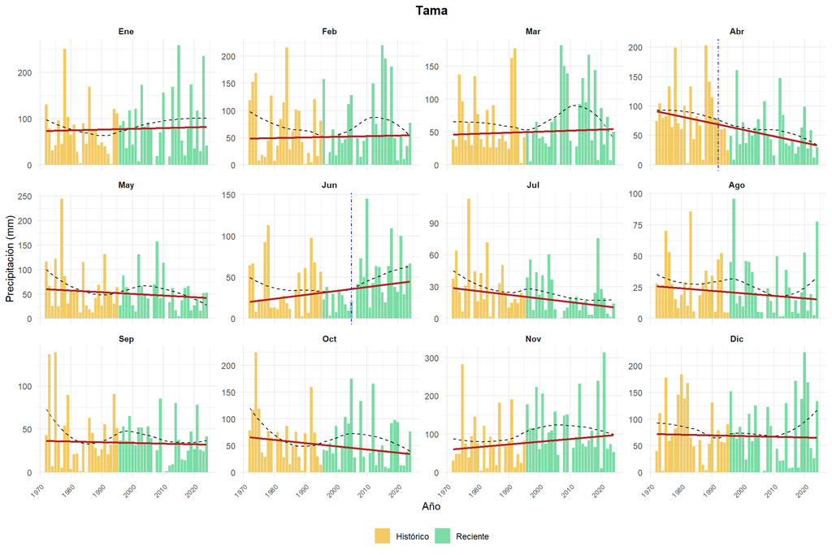

```r
# Gráfica mensual con tendencias (Mann-Kendall, Sen y Pettitt)
plot_prec_mensual_mk <- function(df_raw, mk_mensual, estacion, corte_anio = 1995) {

  meses <- c("Ene","Feb","Mar","Abr","May","Jun","Jul","Ago","Sep","Oct","Nov","Dic")

  # Datos mensuales + periodo
  df <- df_raw %>%
    filter(!is.na(prec)) %>%
    group_by(anio, mes) %>%
    summarise(prec_mensual = sum(prec), .groups = "drop") %>%
    mutate(periodo = ifelse(anio <= corte_anio, "Histórico", "Reciente"),
           mes_label = factor(meses[mes], levels = meses))

  # Líneas de tendencia Sen
  sen_lines <- mk_mensual %>%
    left_join(
      df %>% group_by(mes_label) %>%
        summarise(anio_med = median(anio), val_med = median(prec_mensual),
                  anio_min = min(anio), anio_max = max(anio),
                  .groups = "drop"),
      by = "mes_label"
    ) %>%
    mutate(y_ini = val_med + sen_slope * (anio_min - anio_med),
           y_fin = val_med + sen_slope * (anio_max - anio_med)
    )

  ggplot(df, aes(anio, prec_mensual)) +
    geom_col(aes(fill = periodo), alpha = 0.7) +
    geom_smooth(method = "loess", se = FALSE,
                color = "black", linetype = "dashed", linewidth = 0.5) +
    geom_segment(data = sen_lines, color = "firebrick", linewidth = 1,
                 aes(x = anio_min, xend = anio_max, y = y_ini, yend = y_fin)
    ) +
    geom_vline(data = mk_mensual %>% filter(p_pt < 0.05), aes(xintercept = K_anio),
               color = "blue", linetype = "dotdash"
    ) +
    scale_fill_manual(values = c("Histórico" = "goldenrod2", "Reciente" = "seagreen3"),
                      name = NULL) +
    facet_wrap(~mes_label, scales = "free_y", ncol = 4) +
    labs(title = estacion, x = "Año", y = "Precipitación (mm)") +
    theme_minimal() +
    theme(
      plot.title = element_text(hjust = 0.5, face = "bold"),
      legend.position = "bottom",
      axis.text.x = element_text(size = 7, angle = 45, hjust = 1),
      strip.text = element_text(face = "bold")
    )
}

plot_prec_mensual_mk(datos_tama_sin_NA, mk_mensual_tama, "Tama")
```

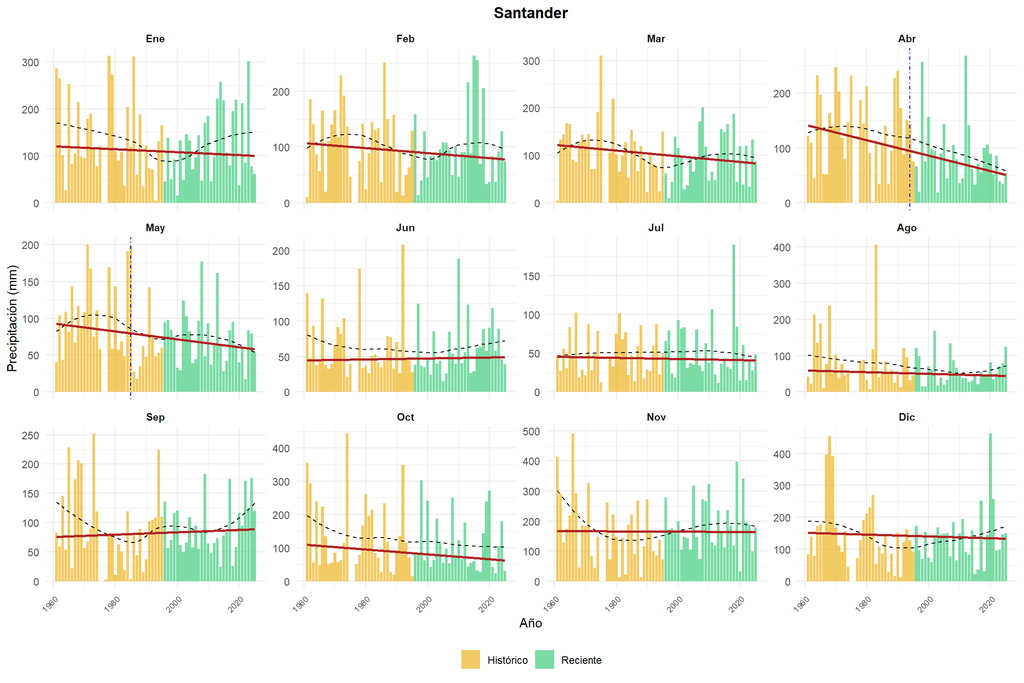

```r
plot_prec_mensual_mk(datos_santander_limpios, mk_mensual_santander, "Santander")
```

## 8.2 - Tendencias estacionales

`tabla_mk_estacional()` aplica el mismo pipeline estadístico a la precipitación estacional, definiendo las cuatro estaciones climáticas como *Invierno* (dic-feb), *Primavera* (mar-may), *Verano* (jun-ago) y *Otoño* (sep-nov). Diciembre se adscribe al año siguiente (`anio_estacional` = `anio` + 1) siguiendo la convención meteorológica habitual. Los resultados se presentan con `mostrar_mk_estacional()` en tablas separadas para Tama y Santander.

```r
# Función para calcular tendencias estacionales con MK, Sen y Pettitt
tabla_mk_estacional <- function(df_raw, estacion_label = "") {

  estaciones <- c("Invierno", "Primavera", "Verano", "Otoño")

  # Calcular precipitación por estación climática
  df <- df_raw %>%
    filter(!is.na(prec)) %>%
    mutate(
      estacion_clima = case_when(mes %in% c(12,1,2) ~ "Invierno", mes %in% c(3,4,5) ~ "Primavera",
                                 mes %in% c(6,7,8) ~ "Verano", TRUE ~ "Otoño"
      ),
      anio_estacional = ifelse(mes == 12, anio + 1, anio)
    ) %>%
    group_by(anio_estacional, estacion_clima) %>%
    summarise(prec_estacional = sum(prec), .groups = "drop")

  map_dfr(estaciones, function(est) {

    serie <- df %>% filter(estacion_clima == est) %>% arrange(anio_estacional)
    vals <- serie$prec_estacional
    anios <- serie$anio_estacional

    if (length(vals) < 10) return(NULL)

    # Selección automática MK con corrección por autocorrelación
    acf1 <- acf(vals, lag.max = 1, plot = FALSE)$acf[2]
    tfpw <- abs(acf1) > 1.96 / sqrt(length(vals))

    mk <- if(tfpw) tfpwmk(vals) else mk.test(vals)

    tau <- if(tfpw) unname(mk[grep("Tau", names(mk), ignore.case = TRUE)])
           else unname(mk$estimates["tau"])

    pval <- if(tfpw) unname(mk[grep("p.value|P.value", names(mk), ignore.case = TRUE)])
            else mk$p.value

    # Tendencia de Sen y cambio de Pettitt
    sen <- sens.slope(vals)
    pt <- pettitt.test(vals)
    k <- as.integer(pt$estimate[1])

    tibble(
      estacion_met = estacion_label,
      estacion_clima = factor(est, levels = estaciones),
      metodo = ifelse(tfpw, "tfpw", "estandar"),
      tau = round(tau, 3),
      p_valor = round(pval, 4),
      sen_slope = round(sen$estimates, 3),
      signif = case_when(pval < 0.01 ~ "**", pval < 0.05 ~ "*", pval < 0.10 ~ ".", TRUE ~ ""),
      K_anio = ifelse(k <= length(anios), anios[k], NA),
      p_pt = round(pt$p.value, 4),
      signif_pt = case_when(pt$p.value < 0.01 ~ "**", pt$p.value < 0.05 ~ "*",
                            pt$p.value < 0.10 ~ ".", TRUE ~ "")
    )
  })
}

mk_estacional_tama <- tabla_mk_estacional(datos_tama_sin_NA, "Tama")
mk_estacional_santander <- tabla_mk_estacional(datos_santander_limpios, "Santander")
```

Resultados de los contrastes de tendencia estacional en Tama

Estación

Método MK

Tau de Kendall

p-valor (MK)

Pendiente de Sen

Signif.

Año de cambio

p-valor (Pettitt)

Signif.

Invierno

estandar

-0.036

0.707

-0.482

1984

0.451

Primavera

estandar

-0.205

0.035

-1.744

1992

0.143

Verano

estandar

-0.016

0.872

-0.099

1978

0.841

Otoño

estandar

0.049

0.615

0.519

1995

0.538

Resultados de los contrastes de tendencia estacional en Santander

Estación

Método MK

Tau de Kendall

p-valor (MK)

Pendiente de Sen

Signif.

Año de cambio

p-valor (Pettitt)

Signif.

Invierno

estandar

-0.145

0.091

-1.650

.

1986

0.029

Primavera

tfpw

-0.325

0.000

-2.483

1991

0.011

Verano

estandar

-0.098

0.260

-0.607

1983

0.381

Otoño

estandar

-0.088

0.313

-1.014

1974

0.290

`plot_prec_estacional_mk()` genera un panel de 4 facetas (2 columnas × 2 filas, una por estación climática) con barras por periodo, curva LOESS, línea de Sen en rojo y líneas de Pettitt significativas en azul discontinuo. Permite identificar qué estaciones del año concentran los cambios y comparar su magnitud entre invierno, primavera, verano y otoño.

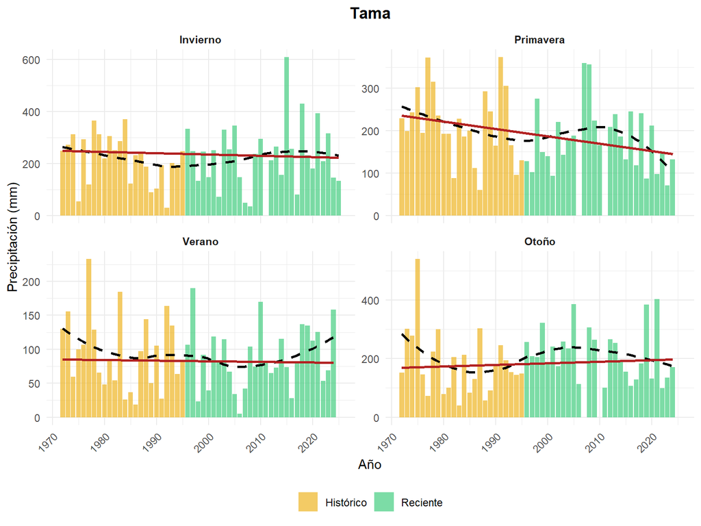

```r
# Gráfico estacional con tendencias (Sen) y cambios (Pettitt)
plot_prec_estacional_mk <- function(df_raw, mk_estacional, estacion, corte_anio = 1995) {

  estaciones_orden <- c("Invierno","Primavera","Verano","Otoño")

  # Datos estacionales
  df <- df_raw %>%
    filter(!is.na(prec)) %>%
    mutate(estacion_clima = case_when(mes %in% c(12,1,2) ~ "Invierno", mes %in% c(3,4,5)   ~ "Primavera",
                                      mes %in% c(6,7,8) ~ "Verano", mes %in% c(9,10,11) ~ "Otoño"),
      anio_estacional = ifelse(mes == 12, anio + 1, anio)
    ) %>%
    group_by(anio_estacional, estacion_clima) %>%
    summarise(prec_estacional = sum(prec), .groups = "drop") %>%
    mutate(periodo = ifelse(anio_estacional <= corte_anio, "Histórico", "Reciente"),
           estacion_clima = factor(estacion_clima, levels = estaciones_orden)
    )

  # Líneas de tendencia Sen
  sen_lines <- mk_estacional %>%
    left_join(
      df %>% group_by(estacion_clima) %>%
        summarise(
          anio_med = median(anio_estacional),
          val_med  = median(prec_estacional),
          anio_min = min(anio_estacional),
          anio_max = max(anio_estacional),
          .groups = "drop"
        ),
      by = "estacion_clima"
    ) %>%
    mutate(y_ini = val_med + sen_slope * (anio_min - anio_med),
           y_fin = val_med + sen_slope * (anio_max - anio_med)
           )

  # Pettitt significativo
  pettitt_sig <- mk_estacional %>%
    filter(p_pt < 0.05, !is.na(K_anio))

  # Gráfico base
  p <- ggplot(df, aes(anio_estacional, prec_estacional)) +
    geom_col(aes(fill = periodo), alpha = 0.7) +
    geom_smooth(method = "loess", se = FALSE, linetype = "dashed", color = "black") +
    geom_segment(data = sen_lines, aes(x = anio_min, xend = anio_max, y = y_ini, yend = y_fin),
                 color = "firebrick", linewidth = 1, inherit.aes = FALSE) +
    scale_fill_manual(values = c("Histórico" = "goldenrod2", "Reciente" = "seagreen3"), name = NULL) +
    facet_wrap(~estacion_clima, scales = "free_y", ncol = 2) +
    labs(title = estacion, x = "Año", y = "Precipitación (mm)") +
    theme_minimal() +
    theme(
      plot.title = element_text(hjust = 0.5, face = "bold"),
      legend.position = "bottom",
      axis.text.x = element_text(angle = 45, hjust = 1),
      strip.text = element_text(face = "bold")
    )

  # Añadir líneas de Pettitt si existen
  if (nrow(pettitt_sig)) {
    p <- p + geom_vline(
      data = pettitt_sig,
      aes(xintercept = K_anio),
      color = "blue", linetype = "dotdash", linewidth = 0.8
    )
  }

  p
}

# Aplicación
plot_prec_estacional_mk(datos_tama_sin_NA, mk_estacional_tama, "Tama")
```

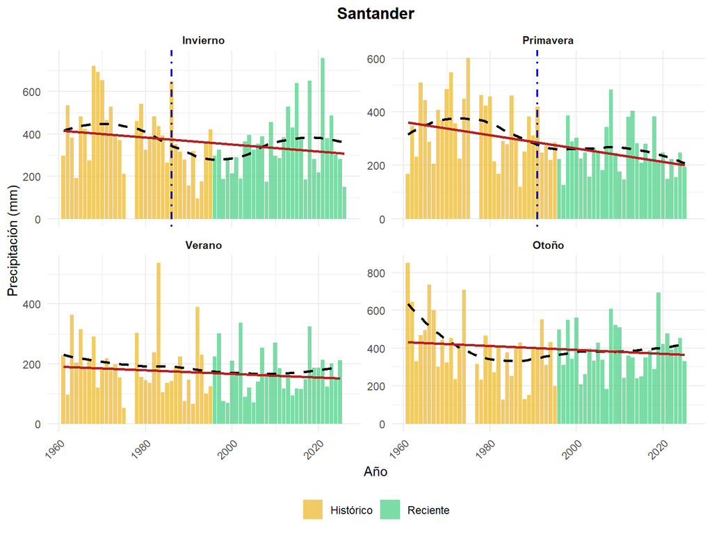

```r
plot_prec_estacional_mk(datos_santander_limpios, mk_estacional_santander, "Santander")
```

# Sección 9 - Índices de concentración, estacionalidad y centroide anual de precipitación

## 9.1 - Tests PCI y SI

`calcular_pci_si()` calcula dos índices anuales de la distribución mensual:

- El PCI (Oliver, 1980) = 100 × Σ(Pᵢ²) / (ΣPᵢ)², que mide la concentración mensual (< 10 uniforme, 10-20 moderado, > 20 irregular)
- El SI (Walsh y Lawler, 1981) = Σ|Pᵢ - R/12| / R, que mide la estacionalidad (de muy uniforme < 0.19 a extremadamente estacional ≥ 1.00).

Solo se incluyen años con los 12 meses disponibles (`n_meses == 12`) para evitar que los meses faltantes distorsionen el denominador de los índices. Se aplica `test_mann_kendall()` a las cuatro series resultantes (PCI y SI de cada estación) y los resultados se presentan en `tabla_mk_indices`.

```r
# ─────────────────────────────────────────────────────────────
# Cálculo del PCI y SI por año
# ─────────────────────────────────────────────────────────────

calcular_pci_si <- function(df_raw, estacion_label="") {

  # ── 1. Precipitación mensual agregada por año-mes ───────────
  df_mensual <- df_raw %>%
    filter(!is.na(prec)) %>%
    group_by(anio, mes) %>%
    summarise(prec_mensual=sum(prec,na.rm=TRUE), .groups="drop")

  # ── 2. Filtrar años completos (solo con 12 meses) ────────────
  anios_completos <- df_mensual %>%
    group_by(anio) %>%
    summarise(n_meses=n(), .groups="drop") %>%
    filter(n_meses==12) %>%
    pull(anio)

  df_mensual <- df_mensual %>%
    filter(anio %in% anios_completos)

  # ── 3. Cálculo de índices PCI y SI ───────────────────────────
  df_mensual %>%
    group_by(anio) %>%
    summarise(
      # PCI: índice de concentración de precipitación
      # <10 uniforme | 10–20 moderado | >20 irregular
      PCI=100*sum(prec_mensual^2)/sum(prec_mensual)^2,

      # SI: índice de estacionalidad (Walsh & Lawler)
      # <0.19 muy uniforme | >1 extremadamente estacional
      R=sum(prec_mensual),
      SI=sum(abs(prec_mensual-R/12))/R,

      .groups="drop"
    ) %>%
    select(-R) %>%
    mutate(estacion=estacion_label)
}

# ─────────────────────────────────────────────────────────────
# Aplicación a estaciones
# ─────────────────────────────────────────────────────────────

pci_si_tama <- calcular_pci_si(datos_tama_sin_NA, "Tama")
pci_si_santander <- calcular_pci_si(datos_santander_limpios, "Santander")
```

```r
# Tests de tendencia sobre PCI y SI
tabla_mk_indices <- bind_rows(test_mann_kendall(pci_si_tama, PCI, "Tama - PCI"),  # PCI
                              test_mann_kendall(pci_si_santander, PCI, "Santander - PCI"),
                              test_mann_kendall(pci_si_tama, SI,  "Tama - SI"),   # SI
                              test_mann_kendall(pci_si_santander, SI, "Santander - SI")
                              )

tabla_mk_indices %>%

  # ─────────────────────────────────────────────────────────────
  # 1. Clasificación de estación e índice desde la variable "serie"
  # ─────────────────────────────────────────────────────────────
  mutate(
    estacion = case_when(grepl("Tama", serie) ~ "Tama", grepl("Santander", serie) ~ "Santander"),
    indice = case_when(grepl("PCI", serie) ~ "PCI", grepl("SI", serie) ~ "SI"),
    estacion = factor(estacion, levels=c("Tama","Santander")),
    indice = factor(indice, levels=c("PCI","SI"))
  ) %>%

  # ─────────────────────────────────────────────────────────────
  # 2. Orden final de la tabla
  # ─────────────────────────────────────────────────────────────
  arrange(estacion, indice) %>%

  # ─────────────────────────────────────────────────────────────
  # 3. Selección de columnas finales
  # ─────────────────────────────────────────────────────────────
  select(estacion, indice, metodo, acf_lag1, tau, p_valor_mk, sen_slope, sen_inf,
         sen_sup, interpretacion, signif_mk, K_anio, p_valor_pt, signif_pt
  ) %>%

  # ─────────────────────────────────────────────────────────────
  # 4. Tabla formateada (kable)
  # ─────────────────────────────────────────────────────────────
  knitr::kable(
    col.names=c("Estación","Índice","Método MK", "ACF lag-1","Tau","p-valor MK",
                "Pendiente Sen", "IC 95% inf.","IC 95% sup.", "Tendencia","Sig. MK",
                "Año cambio","p-valor Pettitt", "Sig. Pettitt"),
    digits=c(NA,NA,NA, 3,4,4,4,4,4, NA,NA, 0,4,NA),
    caption=paste("Tendencias de los índices de concentración de precipitación (PCI) y estacionalidad (SI) mediante Mann-Kendall, Sen y Pettitt.")
  ) %>%

  # ─────────────────────────────────────────────────────────────
  # 5. Estilo visual de la tabla
  # ─────────────────────────────────────────────────────────────
  kableExtra::kable_styling(
    bootstrap_options=c("striped","hover","condensed"),
    full_width=FALSE,
    position="center"
  )
```

Tendencias de los índices de concentración de precipitación (PCI) y estacionalidad (SI) mediante Mann-Kendall, Sen y Pettitt.

| Estación | Índice | Método MK | ACF lag-1 | Tau | p-valor MK | Pendiente Sen | IC 95% inf. | IC 95% sup. | Tendencia | Sig. MK | Año cambio | p-valor Pettitt | Sig. Pettitt |
| --- | --- | --- | --- | --- | --- | --- | --- | --- | --- | --- | --- | --- | --- |
| Tama | PCI | estandar | -0.023 | 0.1333 | 0.2000 | 0.0373 | -0.0276 | 0.1060 | Sin tendencia clara |  | 2009 | 0.1861 |  |
| Tama | SI | estandar | 0.043 | 0.1333 | 0.2000 | 0.0023 | -0.0015 | 0.0056 | Sin tendencia clara |  | 2005 | 0.1444 |  |
| Santander | PCI | estandar | 0.097 | -0.0069 | 0.9419 | -0.0012 | -0.0297 | 0.0249 | Sin tendencia clara |  | 1992 | 0.9203 |  |
| Santander | SI | estandar | 0.111 | 0.0270 | 0.7614 | 0.0002 | -0.0015 | 0.0020 | Sin tendencia clara |  | 2007 | 0.8024 |  |

`plot_indice()` visualiza cualquier índice anual con línea de puntos, curva LOESS discontinua, línea de Sen en rojo y, condicionalmente, el punto de cambio de Pettitt en naranja. La función `añadir_umbrales_si()` superpone las cuatro líneas de referencia horizontales de la clasificación de Walsh y Lawler (0.20, 0.40, 0.60 y 0.80). Los gráficos del PCI se enriquecen manualmente con los umbrales en 10 y 20 mediante anotaciones directas.

```r
# ─────────────────────────────────────────────────────────────
# Función general de gráficos (PCI / SI)
# ─────────────────────────────────────────────────────────────
plot_indice <- function(df, variable, estacion, tabla_mk, serie_label, color_linea="steelblue",
                        ylab="", linea_ref=NULL, label_ref=NULL) {

  # ── Datos MK y estadísticos base ────────────────────────────
  mk_row <- tabla_mk %>% filter(serie==serie_label)

  vals  <- df[[variable]]
  anios <- df$anio

  anio_med <- median(anios)
  val_med  <- median(vals, na.rm=TRUE)

  slope   <- mk_row$sen_slope
  sig_mk  <- mk_row$signif_mk

  sen_df <- tibble(x=c(min(anios),max(anios)),
                   ysen=val_med + slope*(c(min(anios),max(anios))-anio_med)
                   )

  # ── Etiqueta Sen (no usada en plot, pero mantenida) ─────────
  sen_lab <- paste0("Sen: ",sprintf("%+.4f",slope),"/año ",sig_mk)

  # ── Gráfico base ────────────────────────────────────────────
  p <- ggplot(df,aes(x=anio,y=.data[[variable]])) +
    geom_line(color=color_linea,linewidth=.6,alpha=.7) +
    geom_point(color=color_linea,size=1.5,alpha=.6) +
    geom_smooth(method="loess",se=FALSE, color="black",linetype="dashed",linewidth=.7) +
    geom_line(data=sen_df,aes(x=x,y=ysen), color="firebrick",linewidth=1,inherit.aes=FALSE) +
    labs(title=paste(variable,"-",estacion), x="Año", y=ylab) +
    theme_minimal() +
    theme(plot.title=element_text(hjust=.5,face="bold"))

  # ── Línea de referencia opcional ────────────────────────────
  if (!is.null(linea_ref)) {
    p <- p +
      geom_hline(yintercept=linea_ref,color="grey50", linetype="dotted",linewidth=.6) +
      annotate("text",x=min(anios),y=linea_ref, label=label_ref,hjust=0,vjust=-0.4, size=2.8,color="grey40")
  }

  # ── Cambio estructural Pettitt ──────────────────────────────
  k_anio <- mk_row$K_anio

  if (!is.na(k_anio) && mk_row$p_valor_pt < 0.05) {
    p <- p +
      geom_vline(xintercept=k_anio,color="darkorange", linetype="dotdash",linewidth=.8) +
      annotate("text", x=k_anio+0.5, y=max(vals,na.rm=TRUE)*0.95,
               label=paste0("Cambio: ",k_anio," ",mk_row$signif_pt), hjust=0,size=2.8,color="darkorange")
  }

  p
}

# ─────────────────────────────────────────────────────────────
# Función auxiliar: umbrales SI
# ─────────────────────────────────────────────────────────────
añadir_umbrales_si <- function(p) {

  umbrales <- c(0.20,0.40,0.60,0.80)
  etiquetas <- c("0.20 — uniforme con estación húmeda", "0.40 — bastante estacional",
                 "0.60 — estacional","0.80 — muy estacional")

  for (i in seq_along(umbrales)) {
    p <- p +
      geom_hline(yintercept=umbrales[i],color="grey60", linetype="dotted",linewidth=.5) +
      annotate("text",x=-Inf,y=umbrales[i], label=etiquetas[i],
               hjust=-0.03,vjust=-0.4, size=2.5,color="grey45")
  }

  p
}
```

## 9.2 - Centroide

`calcular_centroide()` calcula el día del año en que se ha acumulado el 50% de la precipitación anual total, ordenando los días de cada año por posición calendaria (`dia_anio`, de 1 a 365/366) y localizando el primer día en que la acumulación supera el umbral del 50%. Se excluyen los años con menos de 330 días con dato para evitar que los huecos sesguen el centroide hacia los meses con más registros disponibles.

Se aplica `test_mann_kendall()` a las series de centroide de ambas estaciones. Los resultados se presentan en una tabla con `kableExtra`, incluyendo el IC 95% de la pendiente de Sen. Los gráficos `p_cent_tama` y `p_cent_sant` usan `plot_indice()` con una línea de referencia en el día 182 (1 de julio), que divide el año calendario en dos mitades equivalentes.

```r
# ─────────────────────────────────────────────────────────────
# Centroide de precipitación anual
# (día del año en que se alcanza el 50% de la precipitación)
# ─────────────────────────────────────────────────────────────

calcular_centroide <- function(df_raw, estacion_label="") {

  # ── 1. Preparación de datos (orden temporal + día del año) ───
  df <- df_raw %>%
    filter(!is.na(prec)) %>%
    arrange(anio, mes, dia) %>%
    mutate(fecha = as.Date(paste(anio,mes,dia,sep="-")),
           dia_anio = as.integer(format(fecha,"%j"))
           )

  # ── 2. Cálculo anual del centroide ───────────────────────────
  df %>%
    group_by(anio) %>%
    summarise(prec_total  = sum(prec,na.rm=TRUE), n_dias_dato = sum(!is.na(prec)),

      # Centroide: día en que se alcanza el 50% acumulado
      Centroide = {
        ord <- order(dia_anio)
        prec_ord <- prec[ord]
        dias_ord <- dia_anio[ord]

        umbral <- sum(prec_ord) * 0.5
        idx <- which(cumsum(prec_ord) >= umbral)[1]

        if (!is.na(idx)) dias_ord[idx] else NA_real_
      },

      .groups="drop"
    ) %>%

    # ── 3. Filtrado de años con datos suficientes ─────────────
    filter(n_dias_dato >= 330) %>%
    mutate(estacion=estacion_label)
}

# ─────────────────────────────────────────────────────────────
# Aplicación a estaciones
# ─────────────────────────────────────────────────────────────

centroide_tama      <- calcular_centroide(datos_tama_sin_NA, "Tama")
centroide_santander <- calcular_centroide(datos_santander_limpios, "Santander")
```

```r
# ─────────────────────────────────────────────────────────────
# Tendencia del centroide de precipitación
# ─────────────────────────────────────────────────────────────

tabla_mk_centroide <- bind_rows(test_mann_kendall(centroide_tama, Centroide, "Tama - Centroide"),
                                test_mann_kendall(centroide_santander, Centroide, "Santander - Centroide"))

tabla_mk_centroide %>%
  mutate(
    estacion = factor(
      case_when(grepl("Tama", serie) ~ "Tama", grepl("Santander", serie) ~ "Santander"),
      levels = c("Tama", "Santander")
    ),
    indicador = "Centroide de precipitación"
  ) %>%
  arrange(estacion) %>%
  select(estacion, indicador, metodo, acf_lag1, tau, p_valor_mk, sen_slope, sen_inf, sen_sup,
         interpretacion, signif_mk, K_anio, p_valor_pt, signif_pt
  ) %>%
  knitr::kable(
    col.names = c("Estación","Indicador","Método MK","ACF lag-1","Tau","p-valor MK", "Pendiente Sen",
                  "IC 95% inf.","IC 95% sup.","Tendencia","Sig. MK", "Año cambio","p-valor Pettitt",
                  "Sig. Pettitt"),
    digits = c(NA,NA,NA,3,4,4,4,4,4,NA,NA,0,4,NA),
    caption = paste(
      "Tendencia temporal del centroide de precipitación anual.",
      "El centroide representa el día del año en que se acumula el 50% de la precipitación anual."
    )
  ) %>%
  kableExtra::kable_styling(
    bootstrap_options = c("striped","hover","condensed"),
    full_width = FALSE,
    position = "center"
  )
```

Tendencia temporal del centroide de precipitación anual. El centroide representa el día del año en que se acumula el 50% de la precipitación anual.

| Estación | Indicador | Método MK | ACF lag-1 | Tau | p-valor MK | Pendiente Sen | IC 95% inf. | IC 95% sup. | Tendencia | Sig. MK | Año cambio | p-valor Pettitt | Sig. Pettitt |
| --- | --- | --- | --- | --- | --- | --- | --- | --- | --- | --- | --- | --- | --- |
| Tama | Centroide de precipitación | estandar | -0.098 | 0.0978 | 0.3325 | 0.7232 | -0.7500 | 2.1905 | Sin tendencia clara |  | 1995 | 0.5396 |  |
| Santander | Centroide de precipitación | estandar | 0.148 | 0.0382 | 0.6662 | 0.1750 | -0.6667 | 0.9302 | Sin tendencia clara |  | 2016 | 0.5579 |  |

El panel final `(p_pci_tama | p_pci_sant) / (p_si_tama | p_si_sant) / (p_cent_tama | p_cent_sant)` reúne los seis gráficos de los tres índices para una lectura conjunta de la concentración, estacionalidad y distribución temporal de la precipitación en Cantabria.

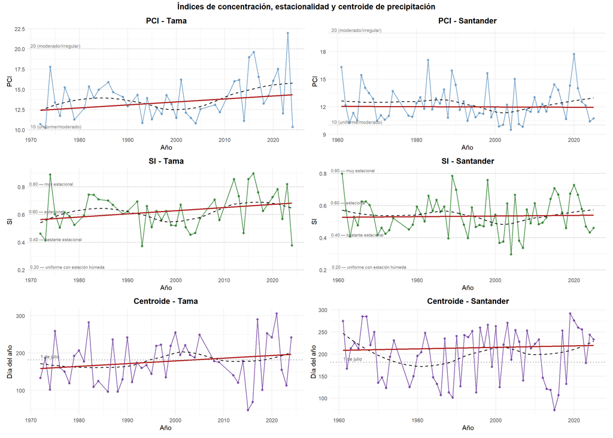

```r
# ─────────────────────────────────────────────────────────────
# PCI: Tama y Santander
# ─────────────────────────────────────────────────────────────
p_pci_tama <- plot_indice(pci_si_tama,"PCI","Tama", tabla_mk_indices,"Tama - PCI",
                          color_linea="steelblue", ylab="PCI") +
  geom_hline(yintercept=c(10,20),color="grey60",linetype="dotted") +
  annotate("text",x=-Inf,y=10,label="10 (uniforme/moderado)",
           hjust=-0.05,vjust=-0.4,size=2.8,color="grey50") +
  annotate("text",x=-Inf,y=20,label="20 (moderado/irregular)",
           hjust=-0.05,vjust=-0.4,size=2.8,color="grey50")

p_pci_sant <- plot_indice(pci_si_santander,"PCI","Santander", tabla_mk_indices,"Santander - PCI",
                          color_linea="steelblue", ylab="PCI") +
  geom_hline(yintercept=c(10,20),color="grey60",linetype="dotted") +
  annotate("text",x=-Inf,y=10,label="10 (uniforme/moderado)",
           hjust=-0.05,vjust=-0.4,size=2.8,color="grey50") +
  annotate("text",x=-Inf,y=20,label="20 (moderado/irregular)",
           hjust=-0.05,vjust=-0.4,size=2.8,color="grey50")

# ─────────────────────────────────────────────────────────────
# SI: Tama y Santander
# ─────────────────────────────────────────────────────────────

p_si_tama <- plot_indice(pci_si_tama,"SI","Tama", tabla_mk_indices,"Tama - SI",
                         color_linea="darkgreen", ylab="SI") %>%
  añadir_umbrales_si()

p_si_sant <- plot_indice(pci_si_santander,"SI","Santander", tabla_mk_indices,"Santander - SI",
                         color_linea="darkgreen", ylab="SI") %>%
  añadir_umbrales_si()

# ─────────────────────────────────────────────────────────────
# Gráfica del centroide de precipitación
# Referencias: 182 ≈ 1 de julio (punto medio del año hidrológico)
# ─────────────────────────────────────────────────────────────

p_cent_tama <- plot_indice(centroide_tama, "Centroide", "Tama",
                           tabla_mk_centroide, "Tama - Centroide",
                           color_linea="purple4", ylab="Día del año",
                           linea_ref=182, label_ref="1 de julio")

p_cent_sant <- plot_indice(centroide_santander, "Centroide", "Santander",
                           tabla_mk_centroide, "Santander - Centroide",
                           color_linea="purple4", ylab="Día del año",
                           linea_ref=182, label_ref="1 de julio")

# Representar en una sola grafica PCI, SI y centroide
(p_pci_tama | p_pci_sant) / (p_si_tama | p_si_sant) / (p_cent_tama | p_cent_sant) +
  plot_annotation(
    title = "Índices de concentración, estacionalidad y centroide de precipitación",
    theme = theme(plot.title = element_text(hjust = 0.5, face = "bold"))
  )
```